# Continuous Distributions

## Purpose of Today

- The Normal Distribution and test statistics.
- Output of linear models.

```r
  load("./data/CukeDatExample.Rda")
  mod.aov <- aov(mean_length ~ Trt*factor(Dens), data = cuke.length.example)
  summary(mod.aov)
```

```
##                  Df Sum Sq Mean Sq F value Pr(>F)
## Trt               2  174.8   87.40   3.327 0.0472 *
## factor(Dens)      1   68.5   68.51   2.608 0.1151
## Trt:factor(Dens)  2   32.3   16.17   0.616 0.5460
## Residuals        36  945.8   26.27
## ---
## Signif. codes:  0 '***' 0.001 '**' 0.01 '*' 0.05 '.' 0.1 ' ' 1
```

## Mathematical Symbols - Integration

\(\int_{lower}^{upper} f(x)dx\) represents the area under the curve of the function \(f(x)\) for some infinitely small slice dx from the set lower and upper bounds.

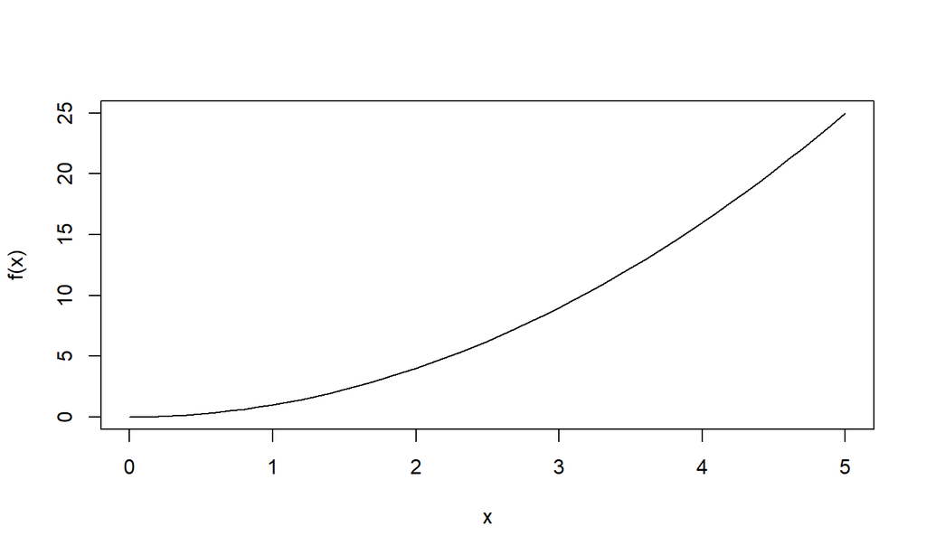

## Integration

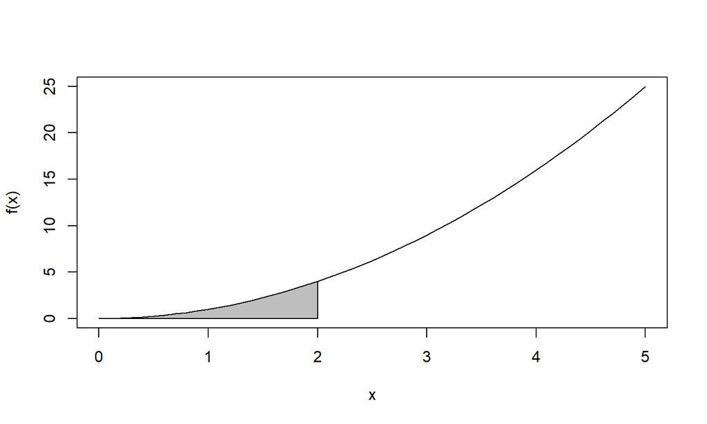

## Integration

1. We can usually solve an integral by summing over small slices.
2. The midpoint rule, \[ \int_0^2 x^2 dx \approx \sum_{i=1}^{100} x_i^2 \times 0.02 \]

```r
  x <- seq(0.01,2, by = 0.02)
  sum(x^2*0.02)
```

```
## [1] 2.6666
```

```r
  ## R has its own numerical integration function:
  integrate(f, 0, 2)
```

```
## 2.666667 with absolute error < 3e-14
```

## Continuous Random Variable

1. A random variable \(X \in (-\infty, \infty)\).
2. Example, measuring fish length.
3. The distribution describing a continuous random variable is called a probability density function (pdf), which we will generally reference as \(f()\).

## Expectation

1. The theoretical or population mean.

\[ \mathbf{E}(X) = \int_{-\infty}^\infty X f(X) \]

## Normal Distribution

1. Randomly occurring around a mean.
2. Defined by the mean (\(\mu\)), and variance (\(\sigma^2\)) and \(X \in \mathcal{R}\).

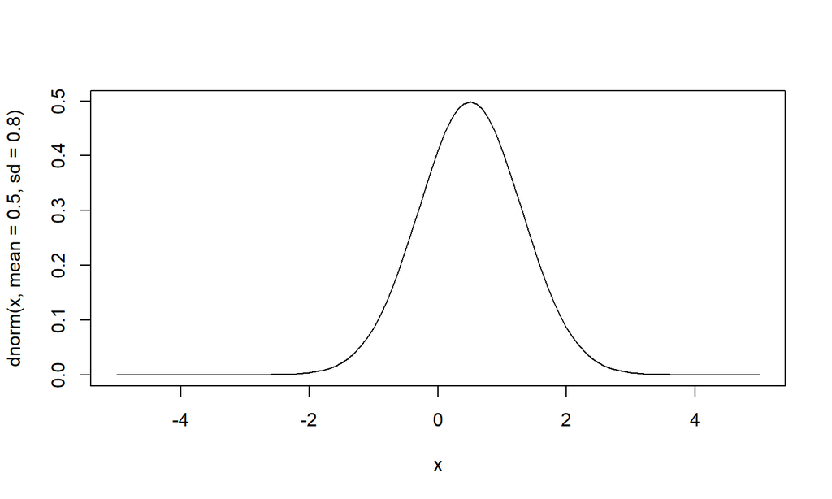

## Standard Normal

1. A normal distribution with mean \(\mu = 0\) and variance \(\sigma^2 = 1\).
2. Often referred to as \(Z\).

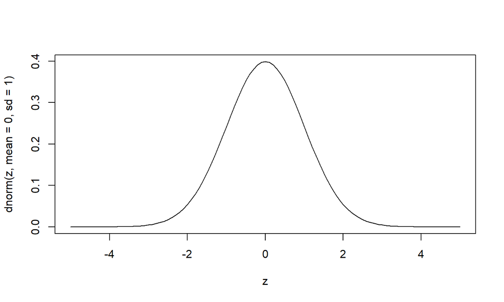

## Central Limit Theorem

- For an average, \(\bar{x}\),

\[ \frac{\bar{x}-\mu}{\sigma/\sqrt{n}} \sim \mathcal{N}(0, 1) \quad \text{as } n\to \infty \]

```r
  means <- NULL
  for(i in 1:100){means <- c(means, mean(rpois(30, 2.5)))}
  z <- sqrt(30)*(means - 2.5)/sqrt(2.5)
```

## Central Limit Theorem

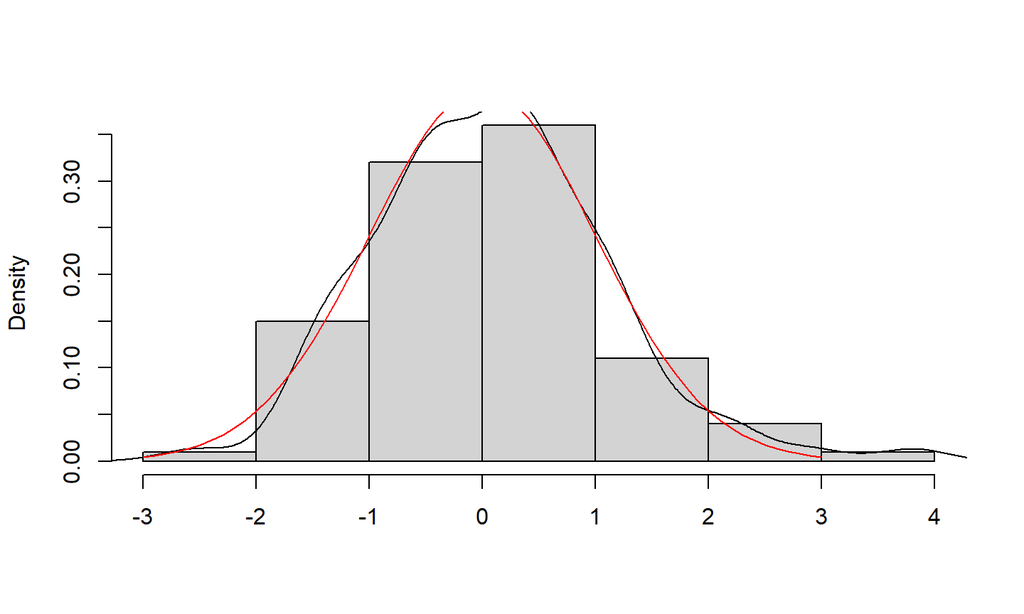

```r
  hist(z, freq = FALSE, xlab = "",  main = "")
  lines(density(z))
  lines(seq(-3,3,0.1), dnorm(seq(-3,3,0.1), 0, 1), col = 'red')
```

## Z Test

- If we know the population variance \(\sigma^2\), and want to test the difference from some mean \(\mu_0\),

\[ Z = \frac{\bar{x} - \mu_0}{\sigma}. \]

\[ Z \sim \text{Normal}(0, 1) \]

- Usually we need to estimate \(\sigma\).

## T Test

- When we estimate \(\sigma^2 \approx \frac{\sum_{i=1}^n(x_i-\bar{x})^2}{n-1} = S^2\).

\[ T = \frac{\bar{x} - \mu_0}{S/\sqrt{n}} \]

\[ T \sim t_{df = n-1} \]

## Student t distribution

The T distribution is essentially a standard normal distribution with fatter tails.

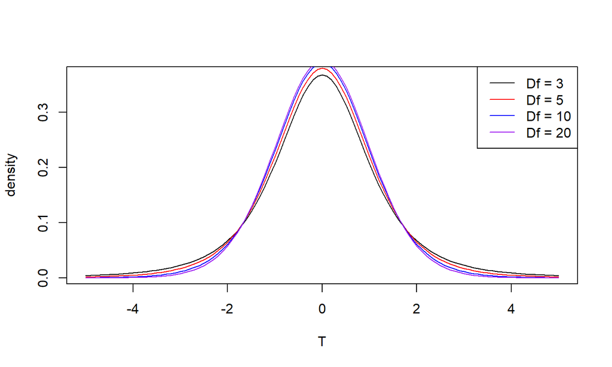

## T Test Example

- Sea cucumber movement distance.
- High Density H TOM vs High Density L TOM.
- \(H_0: \mu_H - \mu_L = 0\).
- \(H_a: \mu_H - \mu_L \neq 0\).

```r
high <- c(9.57, 16.7, 12.9, 8.95, 10.3, 9.88, 11.0)
low <- c(5.27, 5.22, 6.81, 5.62, 2.83, 4.45, 3.42)
```

## Step 1:

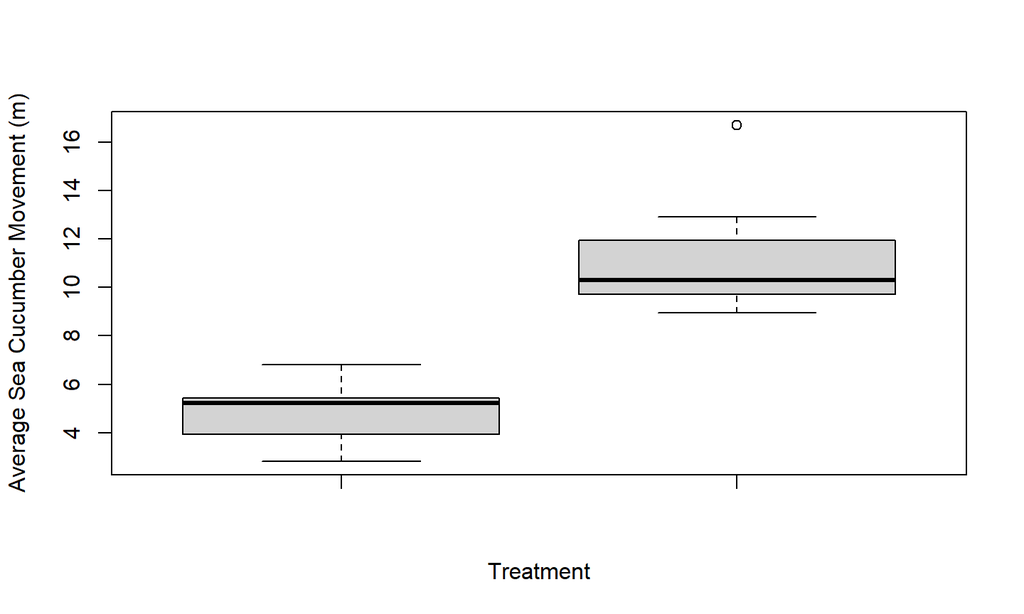

```r
avg.high <- mean(high); sd.high <- sd(high)
avg.low <- mean(low); sd.low <- sd(low)
boxplot(low, high, ylab = "Average Sea Cucumber Movement (m)", xlab = c("Treatment"))
```

## Step 2:

- Calculate the test statistic:
- Mean Difference: \(\bar{x}_H - \bar{x}_L\)
- Variance of \(\bar{x}_H - \bar{x}_L\),

\[ \begin{align} var(\bar{x}_H - \bar{x}_L) &=& var(\bar{x}_H) + var(\bar{x}_L) \\ &=& var(x_H)/n_H + var(x_L)/n_L \end{align} \] - Test Statistic: \[ T = \frac{\bar{x}_H - \bar{x}_L}{\sqrt{var(x_H)/n_H + var(x_L)/n_L}} \]

## Step 3: Degrees of Freedom

- Distribution: \(T \sim t_{df}\), where \(df\) is…

\[ df = \frac{(var(x_H)/n_H + var(x_L)/n_L)^2}{(var(x_H) / n_H)^2 / (n_H – 1) + (var(x_L) / n_L)^2 / (n_L – 1)} \] - If we assumed variance was equal this would be much easier, \(df = n_H + n_L - 2\).

- We will show that test later.

## Step 3:

```r
  nh <- length(high)
  nl <- length(low)
  t.dist <- (mean(high) - mean(low))/
      sqrt(var(high)/length(high) + var(low)/length(low))
  df.t <- (var(high)/nh + var(low)/nl)^2/
      ((var(high)/nh)^2/(nh-1) + (var(low)/nl)^2/(nl-1))
```

```r
  ## T Test Manually
  (pt(-abs(t.dist), df = df.t, ncp = 0))*2
```

```
## [1] 0.0002974081
```

## T Test using the Function

```r
  t.test(high, low, alternative = "two.sided", var.equal = FALSE)
```

```
##
##  Welch Two Sample t-test
##
## data:  high and low
## t = 5.7364, df = 8.8656, p-value = 0.0002974
## alternative hypothesis: true difference in means is not equal to 0
## 95 percent confidence interval:
##  3.946325 9.105104
## sample estimates:
## mean of x mean of y
## 11.328571  4.802857
```

## Visualize the P-Value

- Example: T = 2, df = 5 P-Value = 0.10

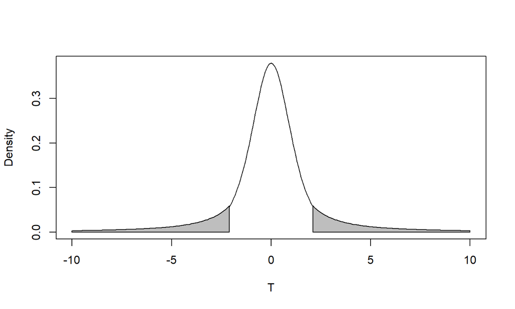

## Visualize the P-Value

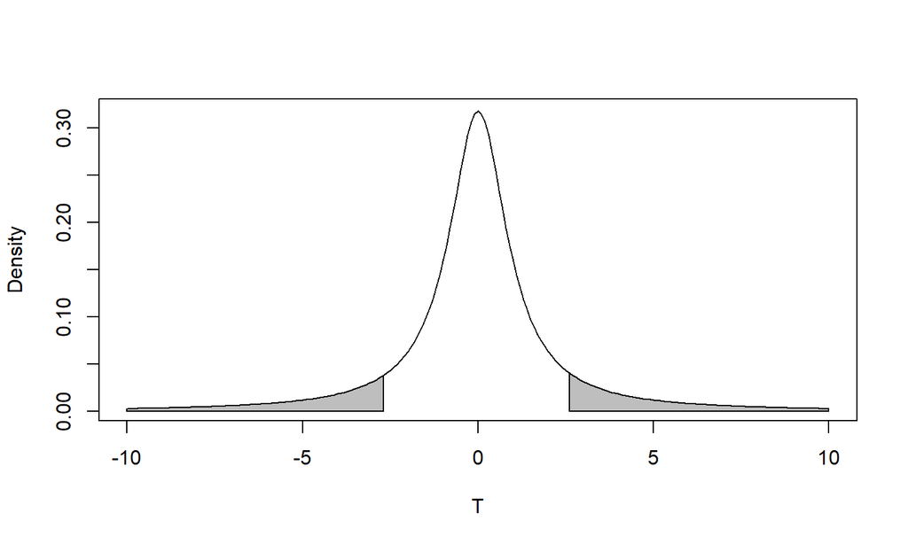

## T Test vs Z Test

- For large sample sizes these are equivalent.
- When we don’t know degrees of freedom, we may use Z test as an approximation.

```r
summary(lm(count~trt, data = dat))
```

```
##
## Call:
## lm(formula = count ~ trt, data = dat)
##
## Residuals:
##    Min     1Q Median     3Q    Max
##   -8.5   -1.6   -0.3    2.6    6.5
##
## Coefficients:
##             Estimate Std. Error t value Pr(>|t|)
## (Intercept)   21.500      1.417  15.173 1.06e-11 ***
## trtB         -14.400      2.004  -7.186 1.09e-06 ***
## ---
## Signif. codes:  0 '***' 0.001 '**' 0.01 '*' 0.05 '.' 0.1 ' ' 1
##
## Residual standard error: 4.481 on 18 degrees of freedom
## Multiple R-squared:  0.7415, Adjusted R-squared:  0.7272
## F-statistic: 51.64 on 1 and 18 DF,  p-value: 1.091e-06
```

## T Test vs Z Test

- For non-normal distributions, we assume asymptotically Normal,

```r
summary(glm(count~trt, data = dat, family = "poisson"))
```

```
##
## Call:
## glm(formula = count ~ trt, family = "poisson", data = dat)
##
## Deviance Residuals:
##      Min        1Q    Median        3Q       Max
## -1.97972  -0.57010  -0.07294   0.76941   1.33884
##
## Coefficients:
##             Estimate Std. Error z value Pr(>|z|)
## (Intercept)   3.0680     0.0682  44.986  < 2e-16 ***
## trtB         -1.1080     0.1369  -8.094 5.75e-16 ***
## ---
## Signif. codes:  0 '***' 0.001 '**' 0.01 '*' 0.05 '.' 0.1 ' ' 1
##
## (Dispersion parameter for poisson family taken to be 1)
##
##     Null deviance: 96.300  on 19  degrees of freedom
## Residual deviance: 20.372  on 18  degrees of freedom
## AIC: 111.03
##
## Number of Fisher Scoring iterations: 4
```

## Chi-Square Distribution

- \(\chi^2\) arises by the sum of squared standard normal distributions.
- Defined by a single degrees of freedom parameter on \(X \in (0, \infty)\).
- Very useful when considering analysis of variance etc.

```r
  norms <- NULL
  for(i in 1:10000){norms <- c(norms, sum(rnorm(5, 0, 1)^2))}
```

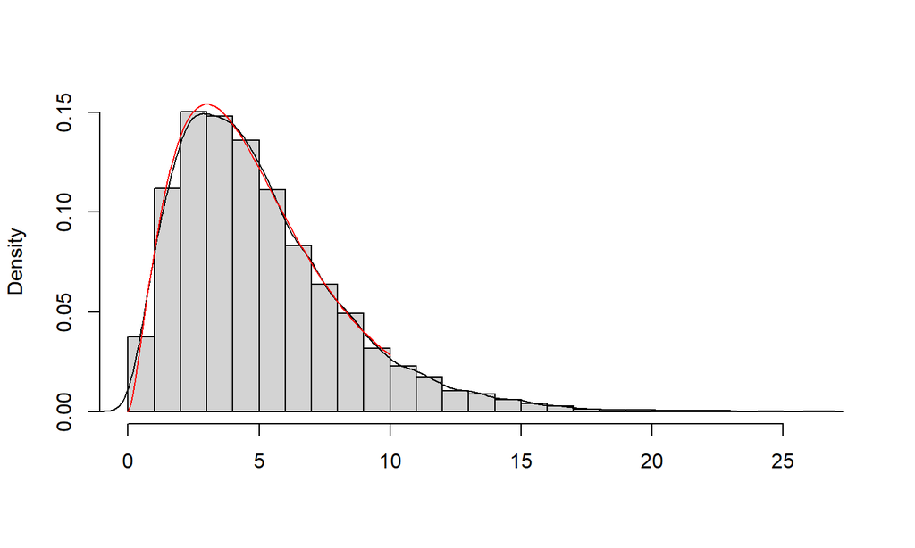

```r
  hist(norms, freq = FALSE, xlab = "",
      main = "", breaks = 20)
  lines(density(norms))
  lines(seq(0, 10, by = 0.1), dchisq(seq(0, 10, by = 0.1), 5), col = 'red')
```

## Chi-Square Distribution

- For \(SS^2 = \sum_{i=1}^n (x_i-\bar{x})^2\),
- We can also think of \(\frac{SS^2}{\sigma^2} \sim \chi^2_{n-1}\)

```r
  vars <- NULL
  for(i in 1:10000){vars <- c(vars, var(rnorm(5, 0, 3.2)))}
  chi.vars <- vars/(3.2^2/4)
```

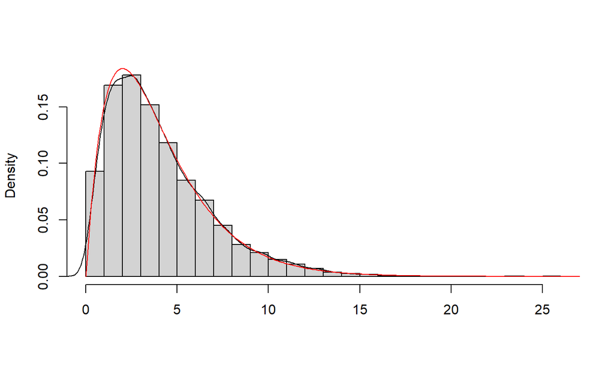

```r
  hist(chi.vars, freq = FALSE, xlab = "",
      main = "", breaks = 20)
  lines(density(chi.vars))
  lines(seq(0, 60, by = 0.1), dchisq(seq(0, 60, by = 0.1), 5-1), col = 'red')
```

## Why is this important?

- Is my variance equal to 1 or greater?
- \(H_0: \, \sigma^2 = 1\)
- \(H_0: \, \sigma^2 > 1\)
- Test Statistic: \[ X = \frac{(n_H-1)var(x_l)}{\sigma^2_0} \]

```r
  X.test <- var(low)*(length(low) - 1)/1
  1-pchisq(X.test, length(low)-1)
```

```
## [1] 0.08783576
```

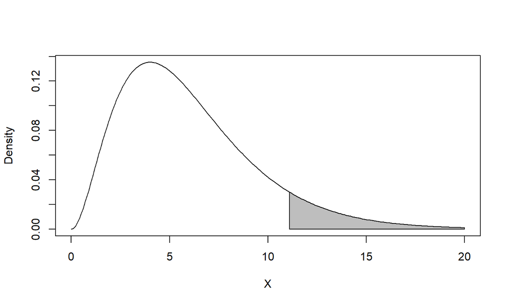

## F-Distribution

- Divide two Chi-squared distributions and their degrees of freedom.
- For \(X\sim \chi^2(5)\) and \(Y \sim \chi^2(3)\), then for

\[ F = \frac{X/5}{Y/3}, \]

\(F \sim F(5,3)\), for \(F \in \mathcal{R}^+\).

```r
  chix <- rchisq(10000, df = 5)
  chiy <- rchisq(10000, df = 3)
  fxy <- (chix/5)/(chiy/3)
```

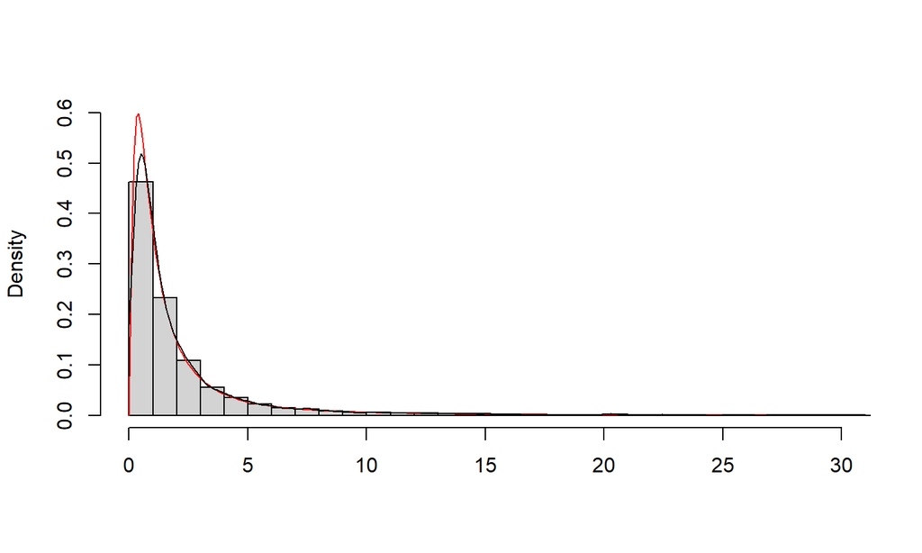

```r
  hist(fxy[fxy<50], freq = FALSE, main = "", xlab = "",
        ylab = "Density", breaks = 50,
        xlim = c(0, 30), ylim = c(0, 0.6))
  lines(seq(0, 30, by = 0.1), df(seq(0, 30, by = 0.1), 5, 3),
      col = 'red')
  lines(density(fxy[fxy<50], from=0))
```

## Why is this important?

- Is variance (\(\sigma^2\)) equal for the high and low sea cucumber data?
- \(H_0: \, \sigma^2_H / \sigma^2_L = 1\)
- \(H_a: \, \sigma^2_H / \sigma^2_L \neq 1\) \[ F = \frac{SS^2_H/(n_h-1)}{SS^2_L/(n_l-1)} \sim F_{n_h-1, n_L-1} \]

```r
  F.var <- (var(high)/length(high))/(var(low)/length(low))
  (1-pf(F.var, length(high)-1, length(low)-1)) + pf(1/F.var, length(high)-1, length(low)-1)
```

```
## [1] 0.120031
```

```r
  var.test(high, low, alt = "two.sided", ratio = 1)
```

```
##
##  F test to compare two variances
##
## data:  high and low
## F = 3.9334, num df = 6, denom df = 6, p-value = 0.12
## alternative hypothesis: true ratio of variances is not equal to 1
## 95 percent confidence interval:
##   0.6758652 22.8912629
## sample estimates:
## ratio of variances
##           3.933371
```

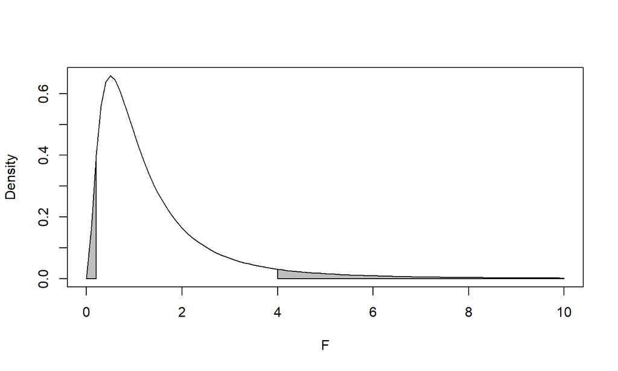

## Back to the T Test

```r
  t.test(high, low, alternative = "two.sided", var.equal = FALSE)
```

```
##
##  Welch Two Sample t-test
##
## data:  high and low
## t = 5.7364, df = 8.8656, p-value = 0.0002974
## alternative hypothesis: true difference in means is not equal to 0
## 95 percent confidence interval:
##  3.946325 9.105104
## sample estimates:
## mean of x mean of y
## 11.328571  4.802857
```

## Equal Variance

```r
  t.test(high, low, alternative = "two.sided", var.equal = TRUE)
```

```
##
##  Two Sample t-test
##
## data:  high and low
## t = 5.7364, df = 12, p-value = 9.361e-05
## alternative hypothesis: true difference in means is not equal to 0
## 95 percent confidence interval:
##  4.047097 9.004332
## sample estimates:
## mean of x mean of y
## 11.328571  4.802857
```

## Exponential Distribution

- If we have events that occur randomly, then the time between those events is exponentially distributed.
- Arises as the time between Poisson events.
- It is parameterized by a single waiting time \(\theta = 1/\lambda\), where \(\lambda\) is the rate of the Poisson distribution.
- \(X \in [0, \infty)\).
- The exponential distribution is ‘memoryless’.
- The mean of an exponential distribution is \(1/\lambda\) and the variance is \(1/\lambda^2\).

```r
  lambda <- 2 # Per second
  t.unif <- sort(runif(rpois(1, lambda*1000), 0, 1000))
  t.diff <- diff(c(0, t.unif))
```

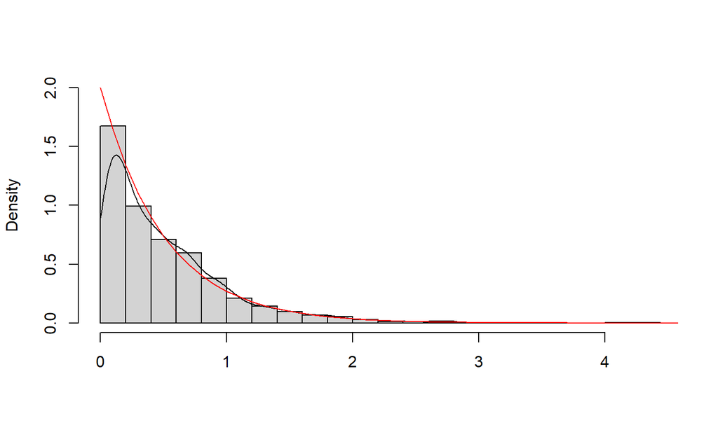

```r
  x.e <- seq(0, 100, by = 0.1)

  hist(t.diff, freq = FALSE, xlab = "", main = "",
      ylim = c(0, 2), breaks = 20)
  lines(density(t.diff, from = 0))
  lines(x.e, dexp(x.e, lambda), col = 'red')
```

## Gamma Distribution

- Sum of independent exponentially distributed random variables.
- Waiting time between two events separated by \(n\) other events.
- The time difference \(X\) is then distributed \(X \sim \text{gamma}(n, \lambda)\).
- The mean of the gamma distribution is \(n/\lambda\) and the variance is \(n/\lambda^2\).

```r
  lambda <- 2 # Per second
  r.sum <- cumsum(rexp(10000, rate = lambda)) # Per second
  t.diff <-  diff(c(0, r.sum), lag = 5)
```

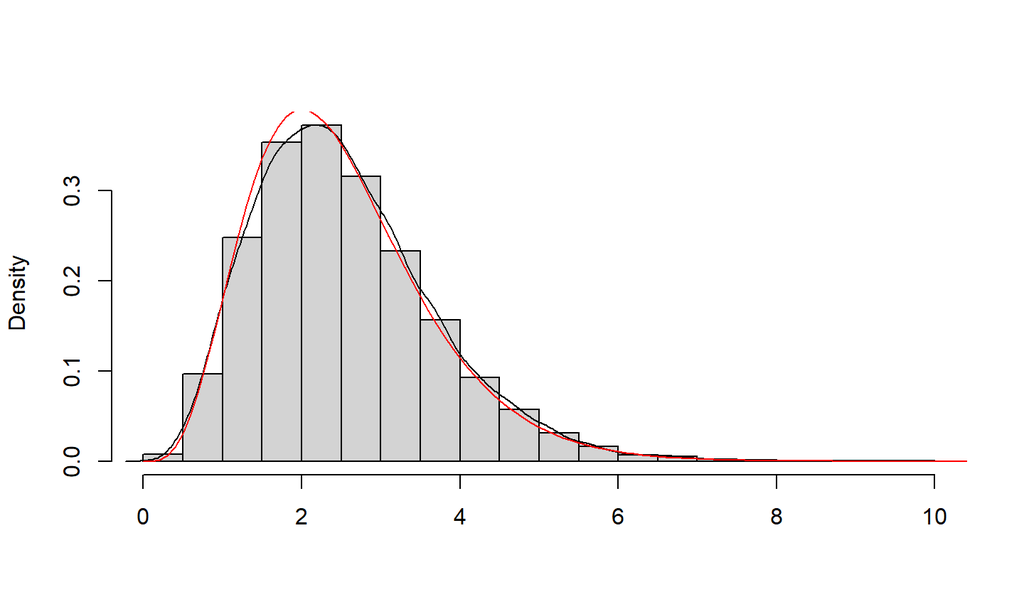

```r
  x.gam <- seq(0,100, by = 0.1)
  hist(t.diff, freq = FALSE, xlab = "", main = "")
  lines(density(t.diff))
  lines(x.gam, dgamma(x.gam, 5, lambda), col = 'red')
```

## Beta Distribution

- A distribution for probabilities.
- Arises from two independent gamma distributed random variables.
- Consider \(X \sim \text{gamma}(1, 5)\) and \(Y \sim \text{gamma}(3, 5)\).
- Then we define a new random variable that is \[ P = \frac{X}{X+Y}, \] then \(P \sim \text{beta}(\text{shape}_1= 1, \text{shape}_2 = 3)\). When both shape parameters are 1, \(\text{beta}(1,1) = \mathcal{U}(0,1)\).

```r
  X <- rgamma(1000, 1, 5)
  Y <- rgamma(1000, 3, 5)
  P <- X/(X+Y)
```

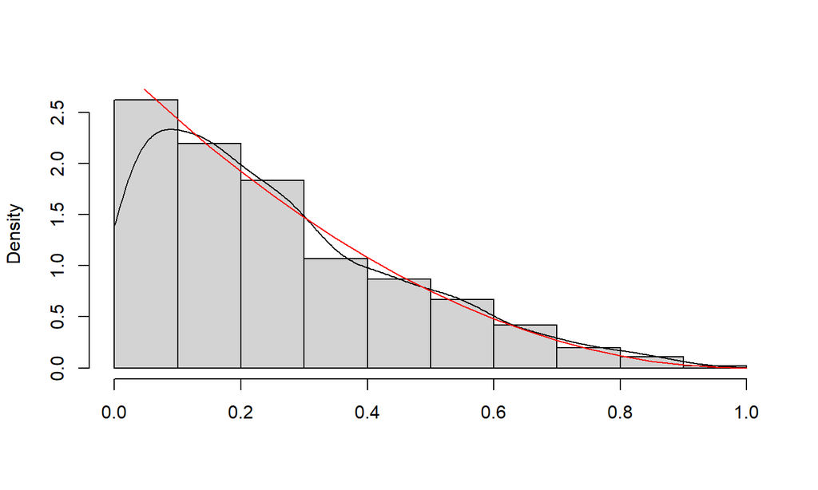

```r
  x.b <- seq(0, 1, by = 0.05)
  hist(P, freq = FALSE, xlab = "", main = "")
  lines(density(P, from = 0, to = 1))
  lines(x.b, dbeta(x.b, 1, 3), col = 'red')
```

## Central Limit Theorm Again!

- Let’s say we record the amount of time until an animal dies under an acidification event.
- Let’s test whether that time is more than 4 days.

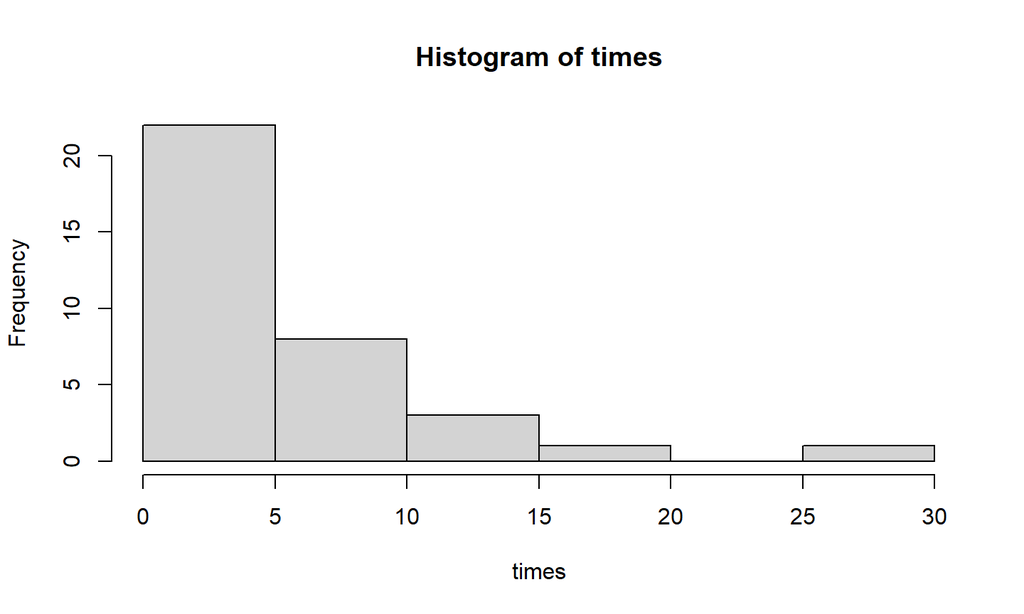

```r
  times <- rexp(35, 1/6)
  hist(times)
```

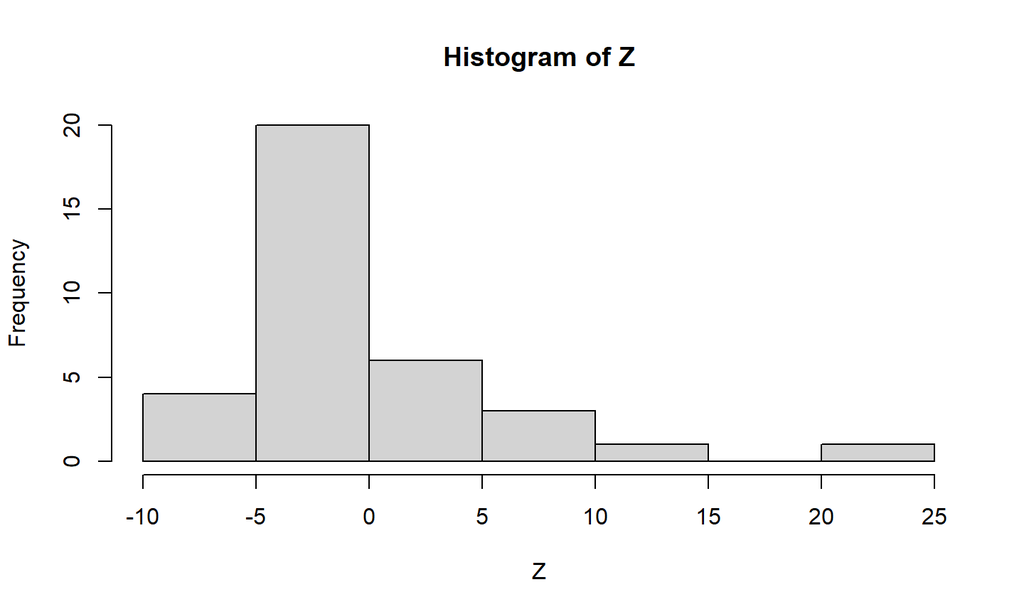

```r
  Z <- (times - mean(times))/(sd(times)/sqrt(length(times)))
  hist(Z)
```

## How Does the T Test Look?

```r
  se.t <- sd(times)/sqrt(length(times))
  T <- (mean(times)-4)/se.t
  T
```

```
## [1] 1.889812
```

```r
  pt(T, df = 34, lower.tail = FALSE)
```

```
## [1] 0.03366699
```

```r
  test1 <- t.test(times, alternative = 'greater', mu = 4)
  test1
```

```
##
##  One Sample t-test
##
## data:  times
## t = 1.8898, df = 34, p-value = 0.03367
## alternative hypothesis: true mean is greater than 4
## 95 percent confidence interval:
##  4.180427      Inf
## sample estimates:
## mean of x
##  5.714402
```

## How Does the T Test Look for n=7?

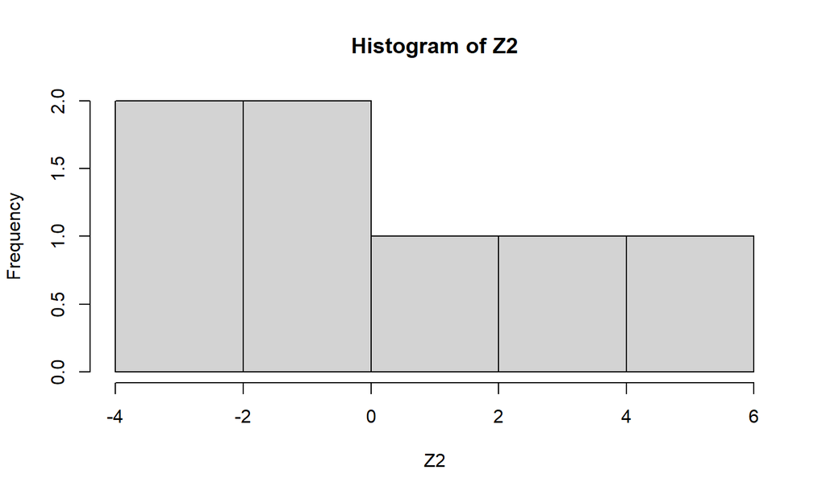

```r
  times2 <- times[1:7]
  Z2 <- (times2-mean(times2))/(sd(times2)/sqrt(7))
  hist(Z2)
```

```r
  test2 <- t.test(times2, alternative = 'greater', mu = 4)
  test2
```

```
##
##  One Sample t-test
##
## data:  times2
## t = 1.2747, df = 6, p-value = 0.1248
## alternative hypothesis: true mean is greater than 4
## 95 percent confidence interval:
##  2.675896      Inf
## sample estimates:
## mean of x
##  6.525065
```

## Confidence Interval

- Confidence Interval is the interval representing where (1-\(\alpha\))% of your values will land if you repeated the experiment multiple times.
- Wald Confidence Interval: For an estimated parameter \(\hat{\theta}\) as

\[ \hat{\theta} \pm z_{\alpha/2} \times \text{SD}(\hat{\theta}), \]

```r
  qnorm(0.975, 0, 1)
```

```
## [1] 1.959964
```

## Confidence Interval Example

```r
  mean.low <- mean(low)
  se.low <- sd(low)/sqrt(length(low))
  lci <- mean.low + se.low*qnorm(0.025)
  uci <- mean.low + se.low*qnorm(0.975)
  paste('Mean: ', round(mean.low,2), ', 95% CI ( ', round(lci, 2), ', ', round(uci, 2), ')')
```

```
## [1] "Mean:  4.8 , 95% CI (  3.8 ,  5.81 )"
```

## Confidence Interval Example

```r
means <- rnorm(1000, mean.low, se.low)
mean(means > lci & means < uci)
```

```
## [1] 0.947
```

## Confidence Interval: Gamma Distribution

```r
  rgam <- rgamma(10, 5, 3)
  mean.gam <- mean(rgam)
  se.gam <- sd(rgam)/sqrt(length(rgam))
  lci <- mean.gam + se.gam*qnorm(0.025)
  uci <- mean.gam + se.gam*qnorm(0.975)
  paste('Mean: ', round(mean.gam,2), ', 95% CI ( ', round(lci, 2), ', ', round(uci, 2), ')')
```

```
## [1] "Mean:  1.75 , 95% CI (  1.2 ,  2.3 )"
```

## Confidence Interval: Gamma Distribution

```r
means <- NULL
for( i in 1:1000 ) means <- c(means, mean(rgamma(10, 5, 3)))
mean(means > lci & means < uci)
```

```
## [1] 0.968
```

## Confidence Interval: Gamma Distribution

```r
  rgam <- rgamma(10, 5, 3)
  mean.gam <- mean(log(rgam))
  se.gam <- sd(log(rgam))/sqrt(length(rgam))
  lci <- exp(mean.gam + se.gam*qnorm(0.025))
  uci <- exp(mean.gam + se.gam*qnorm(0.975))
  paste('Mean: ', round(exp(mean.gam),2), ', 95% CI ( ', round(lci, 2), ', ', round(uci, 2), ')')
```

```
## [1] "Mean:  1.6 , 95% CI (  1.17 ,  2.19 )"
```

## Confidence Interval: Gamma Distribution

```r
means <- NULL
for( i in 1:1000 ) means <- c(means, mean(rgamma(10, 5, 3)))
mean(means > lci & means < uci)
```

```
## [1] 0.961
```

## Bootstrap Confidence Interval

```r
  avgs <- NULL
  for(i in 1:1000){
      avgs <- c(avgs, mean(rgam[sample(length(rgam), 5, replace = TRUE)]))
  }
  ci <- quantile(avgs, c(0.025, 0.975))
  round(ci, 2)
```

```
##  2.5% 97.5%
##  1.11  2.42
```

```r
means <- NULL
for( i in 1:1000 ) means <- c(means, mean(rgamma(10, 5, 3)))
mean(means > ci[1] & means < ci[2])
```

```
## [1] 0.991
```